# LINKEDIN DATASET ASSESMENT

### DESCRIZIONE DATASET

Il dataset assegnatoci contiene i dati di profili LinkedIn anonimi di circa 15000 australiani. Include tutta la storia pregressa dei lavori ottenuti sino a quello corrente, insieme all’analisi particolareggiata delle loro foto.

Librerie

```r
library(dplyr)
library(ggplot2)
library(grid)
library(gridExtra)
library(tidyverse)
```

### ESPLORAZIONE DEL DATASET

A causa della mancanza di metadati dettagliati, sono state assunte le seguenti definizioni per le colonne del dataset.

**avg_n_pos_per_prev_tenure**: numero medio di posizioni occupate negli incarichi precedenti float

**avg_prev_tenure_len**: durata media degli incarichi precedenti float

**avg_pos_len** : la media della durata di ciascuna posizione ricoperta all’interno dell’azienda attuale float

**tenure_len**: la durata complessiva di tutte le posizioni ricoperte all’interno dell’azienda float

**n_prev_tenures** : numero di incarichi precedentemente ottenuti integer

**n_pos** : numero delle posizioni ricoperte all’interno dell’azienda attuale integer

**m_urn** : identificativo dell’utente string

**avg_prev_tenure_len** : media della durata complessiva degli incarichi precedenti ? ??incluso quello attuale??

**c_name** : nome dell’azienda string

**age** : età dell’utente integer

**beauty** : percentuale di bellezza. Se l’utente è uomo corrisponde al valore di beauty_male, mentre se è donna corrisponde al valore di beauty_female. float

**beauty_male** : percentuale di bellezza maschile dell’utente. float

**beauty_female** : percentuale di bellezza femminile dell’utente. float

**blur** : sfocatura dell’immagine integer

**blur_gaussian** : ? integer

**blur_motion** : ? integer

**emo_anger** : valore associato alla rabbia espressa nell’immagine integer

**emo_disgust** : valore associato al disgusto espresso nell’immagine integer

**emo_fear** : valore associato alla paura espressa nell’immagine integer

**emo_happines** : valore associato alla felicità espressa nell’immagine integer

**emo_neutrale** : valore associato alla neutralità dell’espressione integer

**emo_sadness** : valore associato alla tristezza espressa nell’immagine integer

**emo_surprise** : valore associato alla sorpresa espressa nell’immagine integer

**ethnicity** : etnia dell’utente string

**face_quality** : connotati facciali ? float

**gender** : sesso string

**glass** : variabile che esprime la presenza o meno di occhiali nella foto string

**head_pitch** : rotazione della testa rispetto all’asse passante per entrambe le orecchie float

**head_roll** : rotazione della testa rispetto all’asse perpendicolare al naso float

**head_yaw** : rotazione della testa rispetto all’asse verticale float

**img** : url dell’immagine dell’utente string

**mouth_close** : chiusura della bocca float

**mouth_mask** : copertura della bocca float

**mouth_open** : apertura della bocca float

**mouth_other** : ? float

**skin_acne** : presenza di acne sulla pelle float

**skin_dark_circle** : presenza di occhiaie float

**skin_health** : salute della pelle float

**skin_stain** : presenza di macchie sulla pelle float

**smile** : presenza del sorriso float

**african** : valore associato all’etnia africana visibile in foto float

**celtic_english** : valore associato all’etnia celtica visibile in foto float

**east_asian** : valore associato all’etnia est-asiatica visibile in foto float

**european** : valore associato all’etnia europea visibile in foto float

**greek** : valore associato all’etnia greca visibile in foto float

**hispanic** : valore associato all’etnia ispanica visibile in foto float

**jewish** : valore associato all’etnia ebrea visibile in foto float

**muslim** : valore associato all’etnia islamica visibile in foto float

**nationality** : nazionalità string

**nordic** : valore associato all’etnia nordica visibile in foto float

**south_asian** : valore associato all’etnia sud-asiatica visibile in foto float

**n_followers** : numero di seguaci integer

Sotto viene riportato il dataset nella sua interezza:

```r
raw_data <- read.csv(file = "linkedin_data.csv")
raw_data
```

| X | avg_n_pos_per_prev_tenure | avg_pos_len | avg_prev_tenure_len | c_name | m_urn | n_pos | n_prev_tenures | tenure_len | age | beauty | beauty_female | beauty_male | blur | blur_gaussian | blur_motion | emo_anger | emo_disgust | emo_fear | emo_happiness | emo_neutral | emo_sadness | emo_surprise | ethnicity | face_quality | gender | glass | head_pitch | head_roll | head_yaw | … |
| --- | --- | --- | --- | --- | --- | --- | --- | --- | --- | --- | --- | --- | --- | --- | --- | --- | --- | --- | --- | --- | --- | --- | --- | --- | --- | --- | --- | --- | --- | --- |
| 0 | 2.000000 | 457.0000 | 1338.00000 | TD | urn:li:member:149435456 | 1 | 1 | 457 | 37 | 57.570 | 63.829 | 57.570 | 0.421 | 0.421 | 0.421 | 0.766 | 0.007 | 0.007 | 99.035 | 0.086 | 0.007 | 0.091 | Asian | 67.662 | Male | Normal | 7.73504830 | -5.195693000 | 12.39454600 | … |
| 1 | 1.500000 | 212.0000 | 897.50000 | Light Up The World (LUTW) | urn:li:member:149435456 | 1 | 2 | 212 | 37 | 57.570 | 63.829 | 57.570 | 0.421 | 0.421 | 0.421 | 0.766 | 0.007 | 0.007 | 99.035 | 0.086 | 0.007 | 0.091 | Asian | 67.662 | Male | Normal | 7.73504830 | -5.195693000 | 12.39454600 | … |
| 2 | 1.333333 | 243.0000 | 669.00000 | Glacier | urn:li:member:149435456 | 1 | 3 | 243 | 37 | 57.570 | 63.829 | 57.570 | 0.421 | 0.421 | 0.421 | 0.766 | 0.007 | 0.007 | 99.035 | 0.086 | 0.007 | 0.091 | Asian | 67.662 | Male | Normal | 7.73504830 | -5.195693000 | 12.39454600 | … |
| 3 | 1.250000 | 123.0000 | 562.50000 | Sprout App | urn:li:member:149435456 | 1 | 4 | 123 | 37 | 57.570 | 63.829 | 57.570 | 0.421 | 0.421 | 0.421 | 0.766 | 0.007 | 0.007 | 99.035 | 0.086 | 0.007 | 0.091 | Asian | 67.662 | Male | Normal | 7.73504830 | -5.195693000 | 12.39454600 | … |
| 4 | 1.200000 | 244.0000 | 474.60000 | College Pro | urn:li:member:149435456 | 1 | 5 | 244 | 37 | 57.570 | 63.829 | 57.570 | 0.421 | 0.421 | 0.421 | 0.766 | 0.007 | 0.007 | 99.035 | 0.086 | 0.007 | 0.091 | Asian | 67.662 | Male | Normal | 7.73504830 | -5.195693000 | 12.39454600 | … |
| 5 | 1.166667 | 304.0000 | 436.16667 | Microsoft | urn:li:member:149435456 | 1 | 6 | 304 | 37 | 57.570 | 63.829 | 57.570 | 0.421 | 0.421 | 0.421 | 0.766 | 0.007 | 0.007 | 99.035 | 0.086 | 0.007 | 0.091 | Asian | 67.662 | Male | Normal | 7.73504830 | -5.195693000 | 12.39454600 | … |
| 6 | 2.000000 | 457.0000 | 1338.00000 | TD | urn:li:member:149435456 | 1 | 1 | 457 | 37 | 57.570 | 63.829 | 57.570 | 0.421 | 0.421 | 0.421 | 0.766 | 0.007 | 0.007 | 99.035 | 0.086 | 0.007 | 0.091 | Asian | 67.662 | Male | Normal | 7.73504830 | -5.195693000 | 12.39454600 | … |
| 7 | 1.500000 | 212.0000 | 897.50000 | Light Up The World (LUTW) | urn:li:member:149435456 | 1 | 2 | 212 | 37 | 57.570 | 63.829 | 57.570 | 0.421 | 0.421 | 0.421 | 0.766 | 0.007 | 0.007 | 99.035 | 0.086 | 0.007 | 0.091 | Asian | 67.662 | Male | Normal | 7.73504830 | -5.195693000 | 12.39454600 | … |
| 8 | 1.333333 | 243.0000 | 669.00000 | Glacier | urn:li:member:149435456 | 1 | 3 | 243 | 37 | 57.570 | 63.829 | 57.570 | 0.421 | 0.421 | 0.421 | 0.766 | 0.007 | 0.007 | 99.035 | 0.086 | 0.007 | 0.091 | Asian | 67.662 | Male | Normal | 7.73504830 | -5.195693000 | 12.39454600 | … |
| 9 | 1.250000 | 123.0000 | 562.50000 | Sprout App | urn:li:member:149435456 | 1 | 4 | 123 | 37 | 57.570 | 63.829 | 57.570 | 0.421 | 0.421 | 0.421 | 0.766 | 0.007 | 0.007 | 99.035 | 0.086 | 0.007 | 0.091 | Asian | 67.662 | Male | Normal | 7.73504830 | -5.195693000 | 12.39454600 | … |

[output cut: 990 more lines]

*Al fine di sviluppare un’analisi sui data relativi alle assunzioni mediante l’uso dei profili Linkedin, si selezionano i campi di interesse: età, sesso, numero di followers, etnia, bellezza, nazionalità, durata media degli incarichi precedenti, nome della compagnia, numero di incarichi precedenti, numero di posizioni ottenute all’interno della stessa azienda, durata dell’incarico attuale, durata media per posizione ottenuta attualmente nell’azienda.*

*Quindi se la persona ha assunto n posizioni diverse, allora avg_pos_len = tenute_len / n.*

Dopo un’attenta osservazione delle righe del dataset, si è notato che a ciascuna di queste corrisponde non una persona, ma un incarico da essa ottenuto. Per questo motivo a ciascuna persona sono state associate più righe e questo giustifica la dimensione del dataset. E’ stato quindi deciso di tenere conto solamente dell’occupazione più recente, che riassume l’intera carriera del singolo individuo. In questo modo si è ridimensionato il dataset a 15252 righe, rispetto le iniziali 62709.

Si sono inotre riscontrati alcuni errori sui dati riguardanti la *tenure_len*, dove le ore complessive lavorate superavano l’età dell’individuo. E’ stato introdotto a questo proposito un filtro che eliminasse tale inesattezza.

Sono stati selezionati infine i profili di coloro che fossero compresi tra i 16 anni (termine della scuola dell’obbligo) e i 65 anni (età pensionabile), ottenendo di conseguenza un dataset di 14747 righe.

```r
h_working_per_year <- 48*5*8

df <- dplyr::select(raw_data, avg_pos_len, avg_prev_tenure_len, c_name, n_pos, n_prev_tenures, tenure_len, age, beauty, beauty_female, beauty_male,
                   ethnicity, gender, nationality, n_followers, m_urn, smile) %>%
        filter(tenure_len > 0) %>%
        group_by(m_urn) %>%
        arrange(desc(n_prev_tenures)) %>%
        slice(1)%>%
        filter(age>16) %>%
        filter(age<65)%>%
        filter (((age-16)*h_working_per_year)>n_prev_tenures*avg_prev_tenure_len+ tenure_len)

nrow(df)
```

```
[1] 14747
```

```r
df
```

| avg_pos_len | avg_prev_tenure_len | c_name | n_pos | n_prev_tenures | tenure_len | age | beauty | beauty_female | beauty_male | ethnicity | gender | nationality | n_followers | m_urn | smile |
| --- | --- | --- | --- | --- | --- | --- | --- | --- | --- | --- | --- | --- | --- | --- | --- |
| 2345.0000 | 3332.50000 | 360Insight | 1 | 2 | 2345 | 55 | 34.649 | 42.956 | 34.649 | White | Male | celtic_english | 664 | urn:li:member:10001616 | 98.378 |
| 814.2500 | 153.00000 | Orange Business Services | 4 | 1 | 3257 | 47 | 47.491 | 48.449 | 47.491 | White | Male | muslim | 1244 | urn:li:member:100022137 | 98.308 |
| 731.0000 | 77.00000 | Microsoft | 1 | 2 | 731 | 32 | 78.104 | 81.896 | 78.104 | White | Male | celtic_english | 461 | urn:li:member:100023129 | 8.622 |
| 426.0000 | 2729.66667 | Informatica | 1 | 3 | 426 | 50 | 35.416 | 35.416 | 33.303 | Asian | Female | east_asian | 805 | urn:li:member:10002837 | 98.893 |
| 1188.0000 | 1431.00000 | Microsoft | 1 | 5 | 1188 | 34 | 49.165 | 52.821 | 49.165 | Asian | Male | east_asian | 1274 | urn:li:member:100070614 | 11.534 |
| 805.5000 | 1810.50000 | Microsoft | 2 | 2 | 1611 | 62 | 43.382 | 43.382 | 41.989 | White | Female | celtic_english | 140 | urn:li:member:100095413 | 70.392 |
| 1005.0000 | 1901.50000 | KPMG US | 1 | 2 | 1005 | 45 | 47.502 | 46.329 | 47.502 | White | Male | celtic_english | 890 | urn:li:member:1001114 | 5.628 |
| 1127.0000 | 798.62500 | Sky | 1 | 8 | 1127 | 60 | 49.877 | 47.945 | 49.877 | Asian | Male | east_asian | 2147 | urn:li:member:10012899 | 20.274 |
| 458.0000 | 1871.33333 | Neudesic | 1 | 6 | 458 | 53 | 61.024 | 66.158 | 61.024 | White | Male | jewish | 701 | urn:li:member:1001303 | 51.921 |
| 184.0000 | 341.66667 | Gemeente Hengelo | 1 | 9 | 184 | 55 | 38.509 | 38.218 | 38.509 | White | Male | celtic_english | 557 | urn:li:member:10013966 | 77.743 |

[output cut: 990 more lines]

#### RICERCA DEI CAMPI DI INTERESSE

Si analizza ora il dataset risultante per individuare delle prime disuguaglianze riguardanti gli attributi.

###### ethnicity

Si guarda la ripartizione demografica della popolazione. Come si evince dai risultati sotto riportati, vi è una marcata discrepanza tra i bianchi e le altre etnie. Anche nel caso in cui venissero unite le minoranze, tale disuguaglianza viene mantenuta. Tali proporzioni rispecchiano quelle dei dati demografici australiani.

```r
summary(df$ethnicity)
```

```
Asian Black White
 2503  1195 11049
```

```r
n_white <- nrow(df[df$ethnicity=="White",])
n_black <- nrow(df[df$ethnicity=="Black",])
n_asian <- nrow(df[df$ethnicity=="Asian",])
```

###### gender

L’analisi svolta sul genere mostra una disparità tra uomini e donne assunti. Bisogna tuttavvia tenere in considerazione il fatto che le aziende presenti nel dataset sono per la maggior parrte aziende informatiche e ciò potrebbe aver influito fortemente sui dati. Nel caso in cui il dataset dovesse venir utilizzato per allenare un modello predittivo, tali valori rappresenterebbero un alto fattore di rischio. In uno scenario del genere, infatti, potrebbero essere favoriti individui di sesso maschile rispetto a quelli di sesso femminile.

```r
summary(df$gender)
```

```
Female   Male
  3569  11178
```

```r
n_males <- nrow(df[df$gender=="Male",])
n_females <- nrow(df[df$gender=="Female",])
```

###### nationality

Per quanto riguarda la nazionalità emergono alcuni gruppi di minoranze (ad esempio greci e africani), mentre la maggioranza è rappresentata dagli inglesi celtici. Tali valori però rispecchiano la storia del Paese, che è stato colonizzato per oltre due secoli dall’impero brittannico. *discorso su attributi sensibili rispetto alla legge*

```r
summary(df$nationality)
```

```
       african celtic_english     east_asian       european          greek
           118           5492           1491           2350             73
      hispanic         jewish         muslim         nordic    south_asian
          1443             49            870            314           2547
```

Di seguito vengono rappresentati i valori percentuali:

```r
round( summary(df$nationality) / nrow(df) * 100, 2)
```

```
       african celtic_english     east_asian       european          greek
          0.80          37.24          10.11          15.94           0.50
      hispanic         jewish         muslim         nordic    south_asian
          9.79           0.33           5.90           2.13          17.27
```

In primo luogo ci si è concentrati sul genere: ricordando la spropozione di partenza tra uomini e donne, non emerge alcuna discriminazione basata sul sesso.

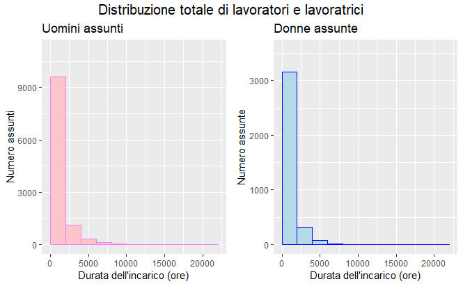

```r
h_male_total <- ggplot(data=filter(df, gender =="Male"), aes(tenure_len)) +
        geom_histogram(breaks=seq(0, 22000, by=2000),
                 col="violet",
                 fill="pink",
                 alpha = .9) +
        labs(title="Uomini assunti", x="Durata dell'incarico (ore)", y="Numero assunti") +
        ylim(c(0,n_males))
h_female_total <- ggplot(data=filter(df, gender =="Female"), aes(tenure_len)) +
        geom_histogram(breaks=seq(0, 22000, by=2000),
                 col="blue",
                 fill="lightblue",
                 alpha = .9) +
        labs(title="Donne assunte", x="Durata dell'incarico (ore)", y="Numero assunte") +
        ylim(c(0,n_females))
title <- textGrob("Distribuzione totale di lavoratori e lavoratrici", gp=gpar(fontsize=15, font=1))
grid.arrange(h_male_total, h_female_total,  ncol = 2, top=title)
```

Si è realizzata successivamente un’analisi più dettagliata, selezionando periodi temporali più specifici. In particolare è stato ritenuto opportuno considerare la soglia dell’anno come indice di competenza della persona sul posto di lavoro. Anche in questo caso dai grafici non si evince alcuna netta disesguaglianza.

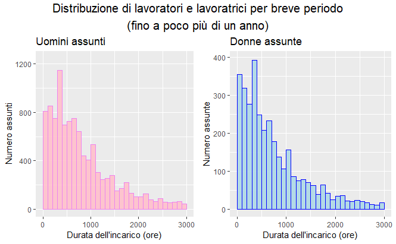

```r
h_male_low <- ggplot(data=filter(df, gender =="Male"), aes(tenure_len)) +
        geom_histogram(breaks=seq(0, 3000, by=100),
                 col="violet",
                 fill="pink",
                 alpha = .9) +
        labs(title="Uomini assunti", x="Durata dell'incarico (ore)", y="Numero assunti") +
        ylim(c(0,n_males/9))
h_female_low <- ggplot(data=filter(df, gender =="Female"), aes(tenure_len)) +
        geom_histogram(breaks=seq(0, 3000, by=100),
                 col="blue",
                 fill="lightblue",
                 alpha = .9) +
        labs(title="Donne assunte", x="Durata dell'incarico (ore)", y="Numero assunte") +
        ylim(c(0, n_females/9))
title <- textGrob("Distribuzione di lavoratori e lavoratrici per breve periodo\n(fino a poco più di un anno)", gp=gpar(fontsize=15, font=1))
grid.arrange(h_male_low, h_female_low,  ncol = 2, top=title)
```

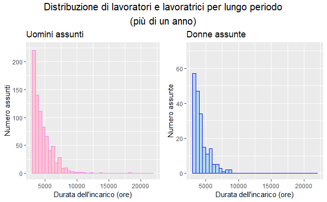

```r
h_male_high <- ggplot(data=filter(df, gender =="Male"), aes(tenure_len)) +
        geom_histogram(breaks=seq(3000, 22000, by=500),
                 col="violet",
                 fill="pink",
                 alpha = .9) +
        labs(title="Uomini assunti", x="Durata dell'incarico (ore)", y="Numero assunti") +
        ylim(c(0,n_males/50))
h_female_high <- ggplot(data=filter(df, gender =="Female"), aes(tenure_len)) +
        geom_histogram(breaks=seq(3000, 22000, by=500),
                 col="blue",
                 fill="lightblue",
                 alpha = .9) +
        labs(title="Donne assunte", x="Durata dell'incarico (ore)", y="Numero assunte") +
        ylim(c(0, n_females/50))
title <- textGrob("Distribuzione di lavoratori e lavoratrici per lungo periodo\n(più di un anno)", gp=gpar(fontsize=15, font=1))
grid.arrange(h_male_high, h_female_high,  ncol = 2, top=title)
```

E’ stata ripetuta la stessa analisi condotta sui generi anche sulle etnie. Ancora una volta, i risultati non hanno mostrato alcuna problematicità.

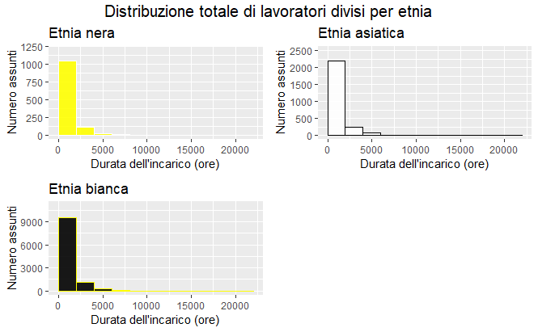

```r
h_black_total <- ggplot(data=filter(df, ethnicity=="Black"), aes(tenure_len)) +
        geom_histogram(breaks=seq(0, 22000, by=2000),
                 col="white",
                 fill="yellow",
                 alpha = .9) +
        labs(title="Etnia nera", x="Durata dell'incarico (ore)", y="Numero assunti") +
        ylim(c(0,n_black))
h_asian_total <- ggplot(data=filter(df, ethnicity=="Asian"), aes(tenure_len)) +
        geom_histogram(breaks=seq(0, 22000, by=2000),
                 col="black",
                 fill="white",
                 alpha = .9) +
        labs(title="Etnia asiatica", x="Durata dell'incarico (ore)", y="Numero assunti") +
        ylim(c(0,n_asian))
h_white_total <- ggplot(data=filter(df, ethnicity =="White"), aes(tenure_len)) +
        geom_histogram(breaks=seq(0, 22000, by=2000),
                 col="yellow",
                 fill="black",
                 alpha = .9) +
        labs(title="Etnia bianca", x="Durata dell'incarico (ore)", y="Numero assunti") +
        ylim(c(0,n_white))
title <- textGrob("Distribuzione totale di lavoratori divisi per etnia", gp=gpar(fontsize=15, font=1))
grid.arrange(h_black_total, h_asian_total, h_white_total,  ncol = 2, top=title)
```

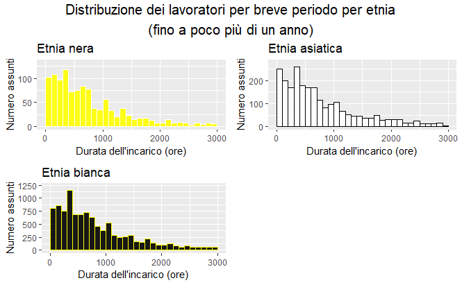

```r
h_white_low <- ggplot(data=filter(df, ethnicity =="White"), aes(tenure_len)) +
        geom_histogram(breaks=seq(0, 3000, by=100),
                 col="yellow",
                 fill="black",
                 alpha = .9) +
        labs(title="Etnia bianca", x="Durata dell'incarico (ore)", y="Numero assunti") +
        ylim(c(0,n_white/9))
h_black_low <- ggplot(data=filter(df, ethnicity =="Black"), aes(tenure_len)) +
        geom_histogram(breaks=seq(0, 3000, by=100),
                 col="white",
                 fill="yellow",
                 alpha = .9) +
        labs(title="Etnia nera", x="Durata dell'incarico (ore)", y="Numero assunti") +
        ylim(c(0, n_black/9))
h_asian_low <- ggplot(data=filter(df, ethnicity =="Asian"), aes(tenure_len)) +
        geom_histogram(breaks=seq(0, 3000, by=100),
                 col="black",
                 fill="white",
                 alpha = .9) +
        labs(title="Etnia asiatica", x="Durata dell'incarico (ore)", y="Numero assunti") +
        ylim(c(0, n_asian/9))
title <- textGrob("Distribuzione dei lavoratori per breve periodo per etnia\n(fino a poco più di un anno)", gp=gpar(fontsize=15, font=1))
grid.arrange(h_black_low, h_asian_low, h_white_low, ncol = 2, top=title)
```

[figure not shown]

```r
h_white_high <- ggplot(data=filter(df, ethnicity =="White"), aes(tenure_len)) +
        geom_histogram(breaks=seq(3000, 22000, by=500),
                 col="yellow",
                 fill="black",
                 alpha = .9) +
        labs(title="Etnia bianca", x="Durata dell'incarico (ore)", y="Numero assunti") +
        ylim(c(0,n_white/50))
h_black_high <- ggplot(data=filter(df, ethnicity =="Black"), aes(tenure_len)) +
        geom_histogram(breaks=seq(3000, 22000, by=500),
                 col="white",
                 fill="yellow",
                 alpha = .9) +
        labs(title="Etnia nera", x="Durata dell'incarico (ore)", y="Numero assunti") +
        ylim(c(0, n_black/50))
h_asian_high <- ggplot(data=filter(df, ethnicity =="Asian"), aes(tenure_len)) +
        geom_histogram(breaks=seq(3000, 22000, by=500),
                 col="black",
                 fill="white",
                 alpha = .9) +
        labs(title="Etnia asiatica", x="Durata dell'incarico (ore)", y="Numero assunti") +
        ylim(c(0, n_asian/50))
title <- textGrob("Distribuzione dei lavoratori per lungo periodo divisi per etnia\n(fino a poco più di un anno)", gp=gpar(fontsize=15, font=1))
grid.arrange(h_black_high, h_asian_high, h_white_high, ncol = 2, top=title)
```

##### not working

A questo punto è stato ritenuto opportuno considerare una parte di dati grezzi inizialmente scartati, ossia coloro che presentavano nel campo *tenure_len* valori nulli. Purtroppo l’esito è marginale rispetto al resto del dataset e dunque non può essere considerato un valido termine di paragone.

```r
not_working <- dplyr::select(raw_data, avg_pos_len, avg_prev_tenure_len, c_name, n_pos, n_prev_tenures, tenure_len, age, beauty, beauty_female, beauty_male,
                   ethnicity, gender, nationality, n_followers, m_urn, smile) %>%
        filter(tenure_len == 0) %>%
        group_by(m_urn) %>%
        arrange(desc(n_prev_tenures)) %>%
        slice(1)%>%
        filter(age>16) %>%
        filter(age<65)%>%
        filter (((age-16)*h_working_per_year)>n_prev_tenures*avg_prev_tenure_len+ tenure_len)
nrow(not_working)
```

```
[1] 329
```

Per completezza sono state effettuate analisi rispetto al genere e all’etnia sull’insieme dei non assunti. *Le percentuali di asiatici, bianchi e neri non assunti è molto simile a quelle degli assunti.*

Per quanto riguarda il *gender* si possono rilevare delle discripenze rispetto al gruppo dei lavoratori, ma probabilmente vi sono troppi pochi campioni per trarre delle conclusioni significative.

```r
summary(not_working$gender)
```

```
Female   Male
   113    216
```

```r
n_males_not_w <- nrow(not_working[not_working$gender=="Male",])
n_females_not_w <- nrow(not_working[not_working$gender=="Female",])
```

Per quanto riguarda l’*ethnicity*, invece, i risultati mostrano che le percentuali di non assunti sono proporzionali a quelle degli assunti.

```r
summary(not_working$ethnicity)
```

```
Asian Black White
   57    29   243
```

```r
n_white_not_w <- nrow(not_working[not_working$ethnicity=="White",])
n_black_not_w <- nrow(not_working[not_working$ethnicity=="Black",])
n_asian_not_w <- nrow(not_working[not_working$ethnicity=="Asian",])
```

Si presenta di seguito una tabella esplicativa:

```r
perc_white_working = n_white/nrow(df)*100
perc_white_not_working = n_white_not_w/nrow(not_working)*100

perc_black_working = n_black/nrow(df)*100
perc_black_not_working = n_black_not_w/nrow(not_working)*100

perc_asian_working = n_asian/nrow(df)*100
perc_asian_not_working = n_asian_not_w/nrow(not_working)*100

perc_females_working = n_females/nrow(df)*100
perc_females_not_working = n_females_not_w/nrow(not_working)*100

perc_males_working = n_males/nrow(df)*100
perc_males_not_working = n_males_not_w/nrow(not_working)*100

perc_table <- matrix(c(perc_white_working, perc_black_working, perc_asian_working, perc_males_working, perc_females_working, perc_white_not_working, perc_black_not_working, perc_asian_not_working, perc_males_not_working, perc_females_not_working), ncol=5, byrow=TRUE)

colnames (perc_table) <- c("White", "Black", "Asian", "Male", "Female")
rownames (perc_table) <- c("Working", "Not working")
perc_table <- as.table(perc_table)
perc_table
```

```
                White     Black     Asian      Male    Female
Working     74.923713  8.103343 16.972944 75.798467 24.201533
Not working 73.860182  8.814590 17.325228 65.653495 34.346505
```

###### beauty

Mantenendo la separazione tra assunti e non assunti, si è posta l’attenzione sulle caratteristiche fisiche della persona. Gli istogrammi non solo non fanno emergere alcuna differenza tra i picchi di bellezza degli assunti e i non assunti, ma addirittura sono straordinariamente simili tra generi.

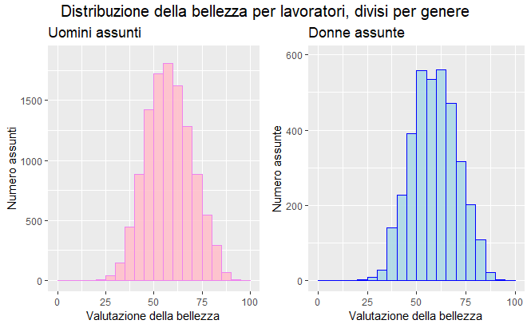

```r
beauty_male <- ggplot(data=filter(df, gender =="Male"), aes(beauty_male)) +
        geom_histogram(breaks=seq(0, 100, by=5),
                 col="violet",
                 fill="pink",
                 alpha = .9) +
        labs(title="Uomini assunti", x="Valutazione della bellezza", y="Numero assunti") +
        ylim(c(0,n_males/6))
beauty_female <- ggplot(data=filter(df, gender =="Female"), aes(beauty_female)) +
        geom_histogram(breaks=seq(0, 100, by=5),
                 col="blue",
                 fill="lightblue",
                 alpha = .9) +
        labs(title="Donne assunte", x="Valutazione della bellezza", y="Numero assunte") +
        ylim(c(0, n_females/6))
title <- textGrob("Distribuzione della bellezza per lavoratori, divisi per genere", gp=gpar(fontsize=15, font=1))
grid.arrange(beauty_male, beauty_female, ncol = 2, top=title)
```

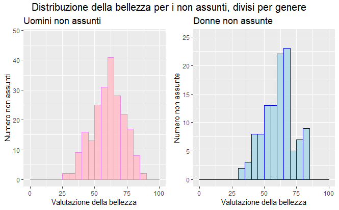

```r
beauty_male_not_w <- ggplot(data=filter(not_working, gender =="Male"), aes(beauty)) +
        geom_histogram(breaks=seq(0, 100, by=5),
                 col="violet",
                 fill="pink",
                 alpha = .9) +
        labs(title="Uomini non assunti", x="Valutazione della bellezza", y="Numero non assunti") +
        ylim(c(0, n_males_not_w/4.5))
beauty_female_not_w <- ggplot(data=filter(not_working, gender =="Female"), aes(beauty)) +
        geom_histogram(breaks=seq(0, 100, by=5),
                 col="blue",
                 fill="lightblue",
                 alpha = .9) +
        labs(title="Donne non assunte", x="Valutazione della bellezza", y="Numero non assunte") +
        ylim(c(0,n_females_not_w/4.5))
title <- textGrob("Distribuzione della bellezza per i non assunti, divisi per genere", gp=gpar(fontsize=15, font=1))
grid.arrange(beauty_male_not_w, beauty_female_not_w, ncol = 2, top=title)
```

Abbiamo selezionato gli uomini e le donne belle a prescindere dall’etnia di appartenenza.

```r
beautiful_males <- dplyr::select(raw_data, avg_pos_len, avg_prev_tenure_len, c_name, n_pos, n_prev_tenures, tenure_len, age, beauty, beauty_female, beauty_male,ethnicity, gender, nationality, n_followers, m_urn, smile) %>%
        filter(tenure_len > 0) %>%
        filter(gender=="Male") %>%
        group_by(m_urn) %>%
        arrange(desc(n_prev_tenures)) %>%
        slice(1)%>%
        filter(age>16) %>%
        filter(age<65)%>%
        filter (((age-16)*h_working_per_year)>n_prev_tenures*avg_prev_tenure_len+ tenure_len) %>%
        filter (beauty>60)
n_beautiful_males <- nrow(beautiful_males)

beautiful_females <- dplyr::select(raw_data, avg_pos_len, avg_prev_tenure_len, c_name, n_pos, n_prev_tenures, tenure_len, age, beauty, beauty_female, beauty_male,ethnicity, gender, nationality, n_followers, m_urn, smile) %>%
        filter(tenure_len > 0) %>%
        filter (gender=="Female")%>%
        group_by(m_urn) %>%
        arrange(desc(n_prev_tenures)) %>%
        slice(1)%>%
        filter(age>16) %>%
        filter(age<65)%>%
        filter (((age-16)*h_working_per_year)>n_prev_tenures*avg_prev_tenure_len+ tenure_len) %>%
        filter (beauty>60)
n_beautiful_females <- nrow(beautiful_females)

ugly_males <- dplyr::select(raw_data, avg_pos_len, avg_prev_tenure_len, c_name, n_pos, n_prev_tenures, tenure_len, age, beauty, beauty_female, beauty_male,ethnicity, gender, nationality, n_followers, m_urn, smile) %>%
        filter(tenure_len > 0) %>%
        filter(gender=="Male") %>%
        group_by(m_urn) %>%
        arrange(desc(n_prev_tenures)) %>%
        slice(1)%>%
        filter(age>16) %>%
        filter(age<65)%>%
        filter (((age-16)*h_working_per_year)>n_prev_tenures*avg_prev_tenure_len+ tenure_len) %>%
        filter (beauty<=60)
n_ugly_males <- nrow(ugly_males)

ugly_females <- dplyr::select(raw_data, avg_pos_len, avg_prev_tenure_len, c_name, n_pos, n_prev_tenures, tenure_len, age, beauty, beauty_female, beauty_male,ethnicity, gender, nationality, n_followers, m_urn, smile) %>%
        filter(tenure_len > 0) %>%
        filter (gender=="Female")%>%
        group_by(m_urn) %>%
        arrange(desc(n_prev_tenures)) %>%
        slice(1)%>%
        filter(age>16) %>%
        filter(age<65)%>%
        filter (((age-16)*h_working_per_year)>n_prev_tenures*avg_prev_tenure_len+ tenure_len) %>%
        filter (beauty<=60)
n_ugly_females <- nrow(ugly_females)
```

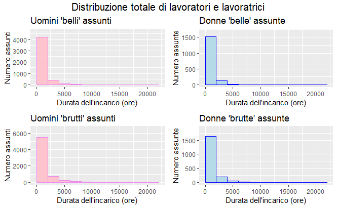

```r
h_male_beautiful <- ggplot(data=filter(beautiful_males), aes(tenure_len)) +
        geom_histogram(breaks=seq(0, 22000, by=2000),
                 col="violet",
                 fill="pink",
                 alpha = .9) +
        labs(title="Uomini 'belli' assunti", x="Durata dell'incarico (ore)", y="Numero assunti") +
        ylim(c(0,n_beautiful_males))
h_female_beautiful <- ggplot(data=filter(beautiful_females), aes(tenure_len)) +
        geom_histogram(breaks=seq(0, 22000, by=2000),
                 col="blue",
                 fill="lightblue",
                 alpha = .9) +
        labs(title="Donne 'belle' assunte", x="Durata dell'incarico (ore)", y="Numero assunte") +
        ylim(c(0,n_beautiful_females))
title <- textGrob("Distribuzione totale di lavoratori e lavoratrici", gp=gpar(fontsize=15, font=1))


h_male_ugly <- ggplot(data=filter(ugly_males), aes(tenure_len)) +
        geom_histogram(breaks=seq(0, 22000, by=2000),
                 col="violet",
                 fill="pink",
                 alpha = .9) +
        labs(title="Uomini 'brutti' assunti", x="Durata dell'incarico (ore)", y="Numero assunti") +
        ylim(c(0,n_ugly_males))
h_female_ugly <- ggplot(data=filter(ugly_females), aes(tenure_len)) +
        geom_histogram(breaks=seq(0, 22000, by=2000),
                 col="blue",
                 fill="lightblue",
                 alpha = .9) +
        labs(title="Donne 'brutte' assunte", x="Durata dell'incarico (ore)", y="Numero assunte") +
        ylim(c(0,n_ugly_females))
# title <- textGrob("Distribuzione totale di lavoratori e lavoratrici 'brutti'", gp=gpar(fontsize=15, font=1))
grid.arrange(h_male_beautiful, h_female_beautiful, h_male_ugly, h_female_ugly,  ncol = 2, nrow=2, top=title)
```

```r
females_working <- dplyr::select(df, beauty, tenure_len, gender, n_prev_tenures,m_urn) %>%
        filter (gender == "Female")
nrow(females_working)
```

```
[1] 3569
```

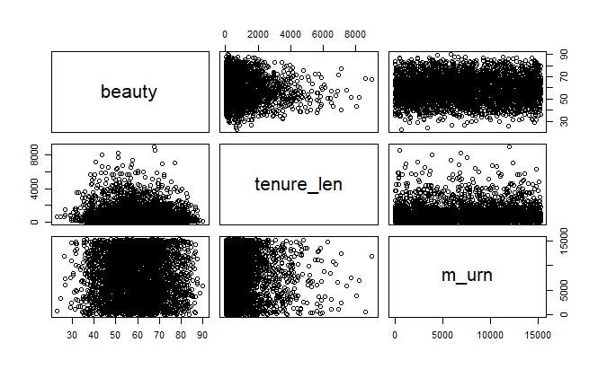

```r
matrix_beauty_len_female <- dplyr::select(females_working, beauty, tenure_len, m_urn)
plot(matrix_beauty_len_female)
```

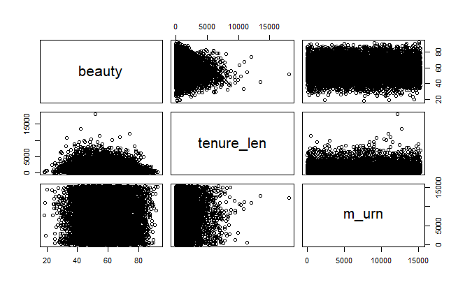

```r
males_working <- dplyr::select(df, beauty, tenure_len, gender,m_urn) %>%
        filter (gender == "Male")
matrix_beauty_len_male <- dplyr::select(males_working, beauty, tenure_len,m_urn)
plot(matrix_beauty_len_male)
```

Dovremmo però vedere se i belli sono assunti per più tempo oppure no.

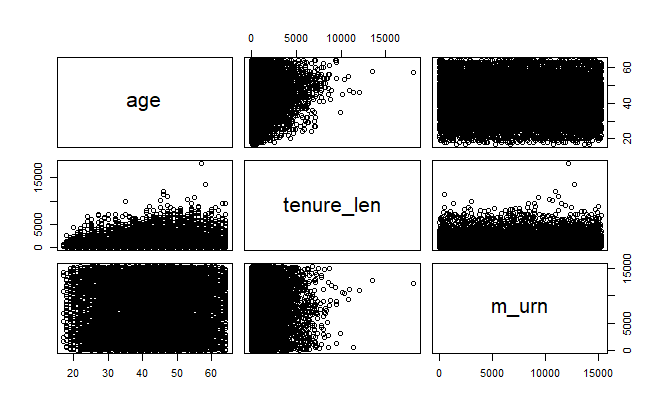

```r
matrix_age_len <- dplyr::select(df, age, tenure_len, m_urn)
plot(matrix_age_len)
```

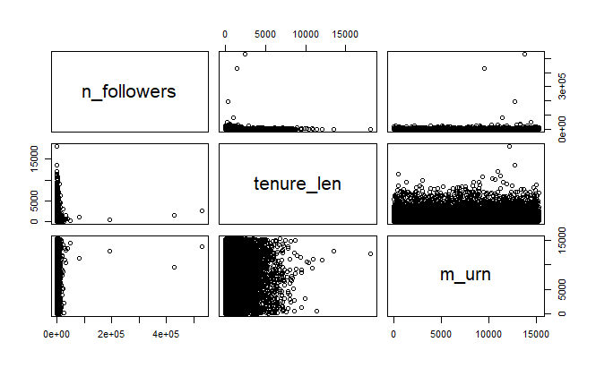

```r
matrix_followers_len <- dplyr::select(df, n_followers, tenure_len,m_urn)
plot(matrix_followers_len)
```

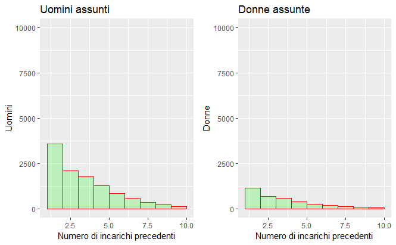

```r
male_prev_pos <- ggplot(data=filter(df, gender =="Male"), aes(n_prev_tenures)) +
        geom_histogram(breaks=seq(1, 10, by=1),
                 col="red",
                 fill="green",
                 alpha = .2) +
        labs(title="Uomini assunti", x="Numero di incarichi precedenti", y="Uomini") +
        ylim(c(0,10000))
female_prev_pos <- ggplot(data=filter(df, gender =="Female"), aes(n_prev_tenures)) +
        geom_histogram(breaks=seq(1, 10, by=1),
                 col="red",
                 fill="green",
                 alpha = .2) +
        labs(title="Donne assunte", x="Numero di incarichi precedenti", y="Donne") +
        ylim(c(0,10000))
grid.arrange(male_prev_pos, female_prev_pos,  ncol = 2)
```

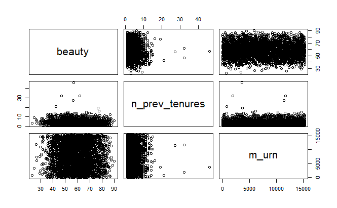

```r
matrix_beauty_prev <- dplyr::select(females_working, beauty, n_prev_tenures,m_urn)
plot(matrix_beauty_prev)
```